# Introduction to proteomics data analysis - MaxQuant Data Dependent Acquisition spike-in study

Author

Affiliation

Lieven Clement, Stijn Vandenbulcke, Oliver M. Crook and Christophe Vanderaa

Ghent University

# 1 Introduction

Label-Free Quantitative mass spectrometry based workflows for differential expression (DE) analysis of proteins is often challenging due to peptide-specific effects and context-sensitive missingness of peptide intensities.

- `msqrob2` provides peptide-based workflows that can assess for DE directly from peptide intensities and outperform summarisation methods which first aggregate MS1 peptide intensities to protein intensities before DE analysis. However, they are computationally expensive, often hard to understand for the non-specialised end-user, and they do not provide protein summaries, which are important for visualisation or downstream processing.
- `msqrob2` therefore also proposes a novel summarisation strategy, which estimates MSqRob’s model parameters in a two-stage procedure circumventing the drawbacks of peptide-based workflows.
- the summarisation based workflow in `msqrob2` maintains MSqRob’s superior performance, while providing useful protein expression summaries for plotting and downstream analysis. Summarising peptide to protein intensities considerably reduces the computational complexity, the memory footprint and the model complexity. Moreover, it renders the analysis framework to become modular, providing users the flexibility to develop workflows tailored towards specific applications.

In this vignette we will demonstrate how to perform `msqrob`’s summarisation based workflow starting from a Maxquant search on a subset of the cptac spike-in study.

Technical details on our methods, and, examples on the analysis of more complex designs and on our peptide-based workflows can be found on our companion website [msqrob2 book](https://statomics.github.io/msqrob2book).

# 2 Background

This case-study is a subset of the data of the 6th study of the Clinical Proteomic Technology Assessment for Cancer (CPTAC). In this experiment, the authors spiked the Sigma Universal Protein Standard mixture 1 (UPS1) containing 48 different human proteins in a protein background of 60 ng/$\mu$L Saccharomyces cerevisiae strain BY4741. Two different spike-in concentrations were used: 6A (0.25 fmol UPS1 proteins/$\mu$L) and 6B (0.74 fmol UPS1 proteins/$\mu$L) [5]. We limited ourselves to the data of LTQ-Orbitrap W at site 56. The data were searched with MaxQuant version 1.5.2.8, and detailed search settings were described in Goeminne et al. (2016) [1]. Three replicates are available for each concentration.

# 3 Load packages

We load the `msqrob2` package, along with additional packages for data manipulation and visualisation.

```r
suppressPackageStartupMessages({
library("QFeatures")
library("dplyr")
library("tidyr")
library("ggplot2")
library("msqrob2")
library("stringr")
library("ExploreModelMatrix")
library("kableExtra")
library("ComplexHeatmap")
library("scater")
})
```

# 4 Data

## 4.1 Peptide table

We first import the data from the peptide.txt file. This is the file containing your peptide-level intensities searched by MaxQuant search, this peptide.txt file can be found by default in the “path_to_raw_files/combined/txt/” folder from the MaxQuant output, with “path_to_raw_files” the folder where the raw files were saved. In this vignette, we use a MaxQuant peptide file which is a subset of the cptac study. This data is available in msqrob2data GitHub repository. To import the data we use the `QFeatures` package.

We generate the object peptideFile with the path to the peptide.txt file. This can be a path to the data on the web or a path to data on your local computer.

```r
peptideFile <- "https://github.com/statOmics/msqrob2data/raw/refs/heads/main/dda/cptacAvsB_lab3/peptides.txt"
```

We will import the data using the `fread` function of the data.table package. We set the `check.names` argument equal to `TRUE` so that all column names are retrieved using the `$` operator.  
We also use argument integer64 = “double” because `readQFeatures` from the `QFeatures` package does not process 64-bit integers correctly.

```r
peptides <- data.table::fread(peptideFile,
                              check.names = TRUE,
                              integer64 = "double")
head(peptides)
```

```
             Sequence N.term.cleavage.window C.term.cleavage.window
               <char>                 <char>                 <char>
1: AAAAGAGGAGDSGDAVTK       EHQHDEQKAAAAGAGG       DSGDAVTKIGSEDVKL
2:          AAAALAGGK       QQLSKAAKAAAALAGG       AAALAGGKKSKKKWSK
3:         AAAALAGGKK       QQLSKAAKAAAALAGG       AALAGGKKSKKKWSKK
4:       AAADALSDLEIK       MPKETPSKAAADALSD       ALSDLEIKDSKSNLNK
5:    AAADALSDLEIKDSK       MPKETPSKAAADALSD       DLEIKDSKSNLNKELE
6:           AAAEEFQR       RERKEREKAAAEEFQR       AAAEEFQRQQELLRQQ
   Amino.acid.before First.amino.acid Second.amino.acid Second.last.amino.acid
              <char>           <char>            <char>                 <char>
1:                 K                A                 A                      T
2:                 K                A                 A                      G
3:                 K                A                 A                      K
4:                 K                A                 A                      I
5:                 K                A                 A                      S
```

[output cut: 121 more lines]

Each row in the peptide data table contains information about one peptide (the table above shows the first 6 rows). The columns contains various descriptors about the peptide, such as its sequence, its charge, the amino acid composition, etc. Some of these columns (those starting with `Intensity`) contain the quantification values for each sample. The table format where the quantitative values for each sample are contained in a separate column is depicted as the “wide format”, as opposed to the “long format” (e.g., the [PSM table]).

```r
quantCols <- grep("Intensity[.]", names(peptides), value = TRUE)
```

Unlike for real experiments, we known the ground truth for this dataset: UPS proteins were spiked in at different concentrations and are thus differentially abundant (DA, spiked in). Yeast proteins consist of the background proteome that is the same in all samples and are thus non-DA.

```r
peptides <- peptides |>
  mutate(species = grepl(pattern = "UPS",Proteins) |>
           as.factor() |>
           recode("TRUE"="ups","FALSE" = "yeast"))
```

## 4.2 Sample annotation

Each row in the annotation table contains information about one sample. The columns contain various descriptors about the sample, such as the name of the sample or the MS run, the treatment (here the spike-in condition), or any other biological or technical information that may impact the data quality or the quantification. Without an annotation table, no analysis can be performed. The sample annotations are generated by the researcher. In this example, the annotations are extracted from the sample names, although reporting a detailed design of experiments in a table is better practice.

1. We first generate a variable quantCols, which contain the names of the quantification columns.
2. Next we generate variable `sampleId`, to pinpoint the different samples in the dataset. Since all quantification columns start with the generic string `Intensity 6` we replace the string with an empty string `""` so we keep the last 3 characters to refer to the sample.
3. We construct a variable condition, by using the first letter of the sampleId, which refers to the spikein condition.
4. We construct a variable rep, by using the third letter of the sampleId.

```r
(annot <- data.frame(quantCols = quantCols) |> #1.
  mutate(sampleId = gsub("Intensity[.]6","", quantCols), #2.
         condition = substr(sampleId,1,1), #3.
         rep = substr(sampleId, 3, 3)) #4.
)
```

```
       quantCols sampleId condition rep
1 Intensity.6A_7      A_7         A   7
2 Intensity.6A_8      A_8         A   8
3 Intensity.6A_9      A_9         A   9
4 Intensity.6B_7      B_7         B   7
5 Intensity.6B_8      B_8         B   8
6 Intensity.6B_9      B_9         B   9
```

## 4.3 Convert to QFeatures

The `readQFeatures()` enables a seamless conversion of tabular data into a `QFeatures` object. We provide the peptide table and the sample annotation table. The function will use the `quantCols` column in the sample annotation table to understand which columns in `peptides` contain the quantitative values, and automatically link the corresponding sample annotation with the quantitative values. We also tell the function to use the `Sequence` column as peptide identifier, which will be used as rownames. See `?readQFeatures()` for more details.

```r
(qf <- readQFeatures(assayData = peptides,
                     colData = annot,
                     name = "peptides",
                     fnames = "Sequence")
)
```

```
Checking arguments.
```

```
Loading data as a 'SummarizedExperiment' object.
```

```
Formatting sample annotations (colData).
```

```
Formatting data as a 'QFeatures' object.
```

```
Setting assay rownames.
```

```
An instance of class QFeatures (type: bulk) with 1 set:

 [1] peptides: SummarizedExperiment with 11466 rows and 6 columns
```

# 5 Data preprocessing

Since we have a `QFeatures` object, we can directly make use of `QFeatures’` data preprocessing functionality. A major advantage of QFeatures is it provides the power to build highly modular workflows, where each step is carried out by a dedicated function with a large choice of available methods and parameters. This means that users can adapt the workflow to their specific use case and their specific needs.

## 5.1 Encoding missing values

The first preprocessing step is to correctly encode the missing values. It is important that missing values are encoded using `NA`. For instance, non-observed values should not be encoded with a zero because true zeros (the proteomic feature is absent from the sample) cannot be distinguished from technical zeros (the feature was missed by the instrument or could not be identified). We therefore replace any zero in the quantitative data with an `NA`.

```r
qf <- zeroIsNA(qf, "peptides") # convert 0 to NA
```

Note that `msqrob2` can handle missing data without having to rely on hard-to-verify imputation assumptions, which is our general recommendation. However, `msqrob2` does not prevent users from using imputation, which can be performed with `impute()` from the QFeatures package.

## 5.2 $\log_2$ transformation

We perform log2-transformation with `logTransform()` from the `QFeatures` package.

```r
qf <- logTransform(qf, base = 2, i = "peptides", name = "peptides_log")
```

## 5.3 Peptide-Filtering

Filtering removes low-quality and unreliable peptides that would otherwise introduce noise and artefacts in the data.

### 5.3.1 Remove failed protein inference

We remove peptides that could not be mapped to a protein. We also remove peptides that cannot be uniquely mapped to a single proteins because its sequence is shared across multiple proteins. This often occurs for homologs or for proteins that share similar functional domains. Shared peptides are often mapped to protein groups, which are the set of proteins that share the given peptides. Protein groups are encoded by appending the constituting protein identifiers, separated by a `";"`.

```r
qf <- filterFeatures(
  qf, ~ Proteins != "" & ## Remove failed protein inference
    !grepl(";", Proteins)) ## Remove protein groups
```

```
'Proteins' found in 2 out of 2 assay(s).
```

### 5.3.2 Remove reverse sequences and contaminants

We now remove the peptides that map to decoy sequences or to contaminants proteins. In our `peptide.txt` file decoys and contaminants are indicated with a “+” character in the column `Reverse` and `Potential.contaminant`, respectively. Note, that depending on the version of MaxQuant the name of the contaminant variable differs (e.g. `Contaminant` or `Potential contaminant`). Note, that while reading in the `peptides` table spaces in the column names are replaced by a dot.

```r
qf <- filterFeatures(qf, ~ Reverse != "+" & ## Remove decoys
                          Potential.contaminant != "+") ## Remove contaminants
```

```
'Reverse' found in 2 out of 2 assay(s).'Potential.contaminant' found in 2 out of 2 assay(s).
```

### 5.3.3 Remove highly missing peptides

The data are characterised by a high proportion of missing values as reported by `nNA()` from the `QFeatures` package. The function computes the number and the proportion of missing values across peptides, samples or for the whole data set and return a list of three tables called `nNArows`, `nNAcols`, and `nNA`, respectively.

```r
nNaRes <- nNA(qf, "peptides")
range(nNaRes$nNAcols$pNA)
```

```
[1] 0.4245165 0.4963918
```

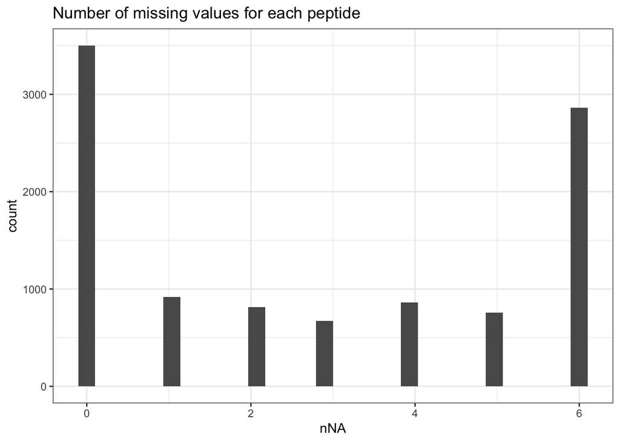

```r
data.frame(nNaRes$nNArows) |>
  ggplot() +
  aes(x = nNA) +
  geom_histogram() +
  ggtitle("Number of missing values for each peptide") +
  theme_bw()
```

We keep peptides that were observed at last 3 times out of the $n = 6$ samples, so that we can estimate the peptide characteristics. We tolerate the following proportion of NAs: $\text{pNA} = \frac{(n - 3)}{n} = 0.5$, so we keep peptides that are observed in at least 50% of the samples, which corresponds to one treatment condition. This is an arbitrary value that may need to be adjusted depending on the experiment and the data set.

```r
nObs <- 3
n <- ncol(qf[["peptides_log"]])
(qf <- filterNA(qf, i = "peptides_log", pNA = (n - nObs) / n))
```

```
An instance of class QFeatures (type: bulk) with 2 sets:

 [1] peptides: SummarizedExperiment with 10393 rows and 6 columns
 [2] peptides_log: SummarizedExperiment with 5910 rows and 6 columns
```

We keep 5910 peptides upon filtering.

## 5.4 Normalisation

The most common objective of MS-based proteomics experiments is to understand the biological changes in protein abundance between experimental conditions. However, changes in measurements between groups can be caused due to technical factors. For instance, there are systematic fluctuations from run-to-run that shift the measured intensity distribution. We can this explore as follows:

1. We extract the sets containing the log transformed data. This is performed using `QFeatures`’ 3-way subsetting.
2. We use `longForm()` to convert the `QFeatures` object into a long table, including all `colData` for filtering and colouring.
3. We visualise the density of the quantitative values within each sample. We colour each sample based on its spike-in condition.

```
harmonizing input:
  removing 6 sampleMap rows not in names(experiments)
```

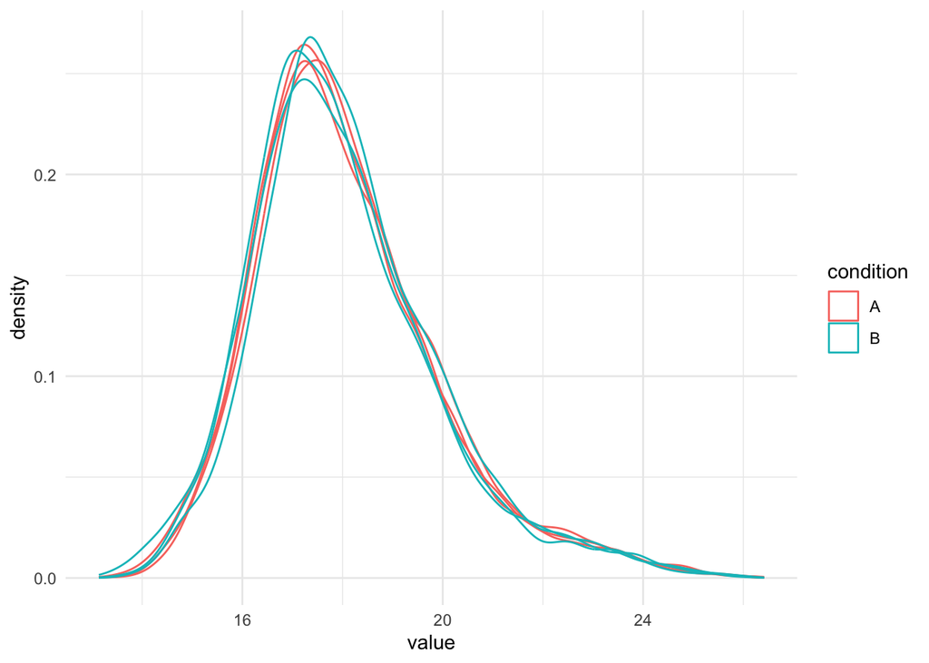

```r
qf[, , "peptides_log"] |> #1.
  longForm(colvars = colnames(colData(qf))) |>  #2.
  data.frame() |>
  filter(!is.na(value)) |>
  ggplot() + #3.
  aes(x = value,
      colour = condition,
      group = colname) +
  geom_density() +
  theme_minimal()
```

Even in this clean synthetic data set (same yeast background with some spiked UPS proteins), the marginal precursor intensity distributions across samples are not well aligned. Ignoring this effect will increase the noise and reduce the statistical power of the experiment, and may also, in case of unbalanced designs, introduce confounding effects that will bias the results.

There are many ways to perform the normalisation, e.g.  
median centering is a popular choice. If we subtract the sample median at the log scale from each precursor log2 intensity, this basically boils down to calculating log-ratio’s between the precursor intensity and its sample median. Here, we choose to work with offsets, that are chosen in such a way so that the distributions are centered around the location of a reference sample. E.g. the median of the sample medians.

Note that users can also use all normalisation functions that are provided in QFeatures, i.e. by replacing the sweep function by `QFeatures::normalize`.

```r
qf <- sweep( #Subtract log2 norm factor column-by-column (MARGIN = 2)
  qf,
  MARGIN = 2,
  STATS = nfLogMedianOfRatios(qf,"peptides_log"),
  i = "peptides_log",
  name = "peptides_norm"
)
```

```
This function aims to calculate norm factors on a log scale,
          the input data are assumed to be on the log-scale!
```

We explore the effect of the global normalisation in the subsequent plot.

Formally, the function applies the following operation on each sample $i$ across all precursors $p$:

$$y_{ip}^{\text{norm}} = y_{ip} - \log_2(nf_i)$$

with $y_{ip}$ the log2-transformed intensities and $\log_2(nf_i)$ the log2-transformed norm factor. Upon normalisation, we can see that the distribution of the $y_{ip}^{\text{norm}}$ nicely overlap (using the same code as above)

```
harmonizing input:
  removing 12 sampleMap rows not in names(experiments)
```

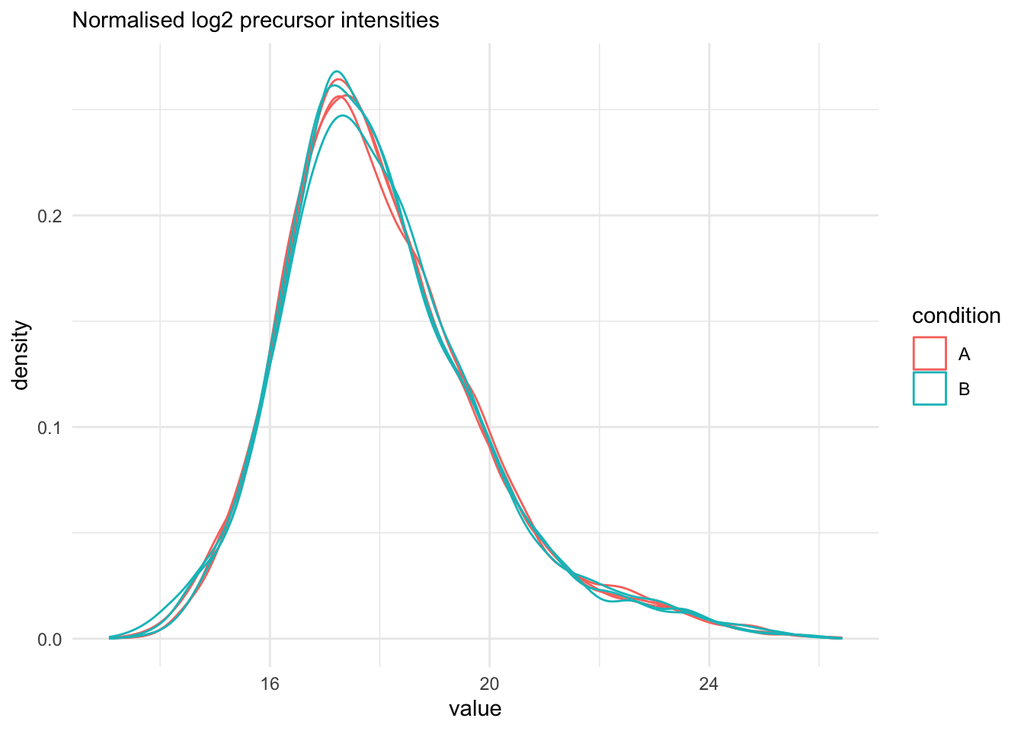

```r
qf[, , "peptides_norm"] |>
  longForm(colvars = colnames(colData(qf))) |>
  data.frame() |>
  filter(!is.na(value)) |>
  ggplot() +
  aes(x = value,
      colour = condition,
      group = colname) +
  geom_density() +
  labs(subtitle = "Normalised log2 precursor intensities") +
  theme_minimal()
```

## 5.5 Summarization to protein level

Here, we summarise the peptide-level data into protein intensities using `aggregateFeatures()`, which streamlines summarisation. It requires the name of a `rowData` column to group the peptides into proteins (or protein groups), here `Proteins`. We can provide the summarisation approach through the `fun` argument. We use the standard summarisation in aggregateFeatures, which is a robust summarisation method.

```r
qf <- aggregateFeatures(qf,
    i = "peptides_norm",
    fcol = "Proteins",
    na.rm = TRUE,
    name = "proteins"
)
```

```
The following messages occurred during aggregation:
```

[output not shown]

Note, that robust summarisation can take a long time for large datasets. In that case we suggest to use `fun = MsCoreUtils::medianPolish, na.rm = TRUE`. Note that the optional argument na.rm = TRUE is needed when using `medianPolish` because the data contains missing values as we did not adopt imputation and `medianPolish` by default cannot handle missing values.

# 6 Data exploration and QC

Data exploration aims to highlight the main sources of variation in the data prior to data modelling and can pinpoint to outlying or off-behaving samples.

## 6.1 Marginal distribution at precursor and protein level

```
harmonizing input:
  removing 18 sampleMap rows not in names(experiments)
```

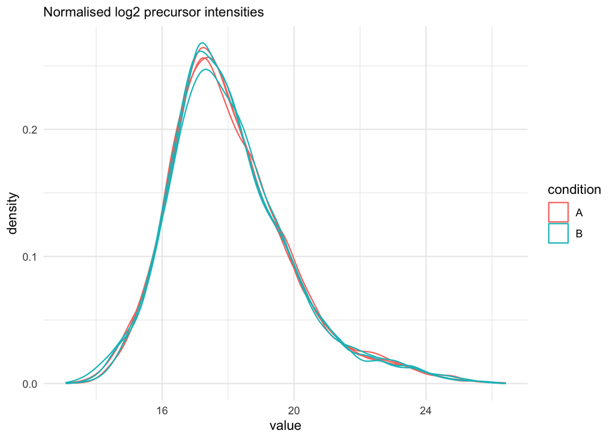

```r
qf[, , "peptides_norm"] |>
  longForm(colvars = colnames(colData(qf))) |>
  data.frame() |>
  filter(!is.na(value)) |>
  ggplot() +
  aes(x = value,
      colour = condition,
      group = colname) +
  geom_density() +
  theme_minimal() +
   labs(subtitle = "Normalised log2 precursor intensities")
```

```
harmonizing input:
  removing 18 sampleMap rows not in names(experiments)
```

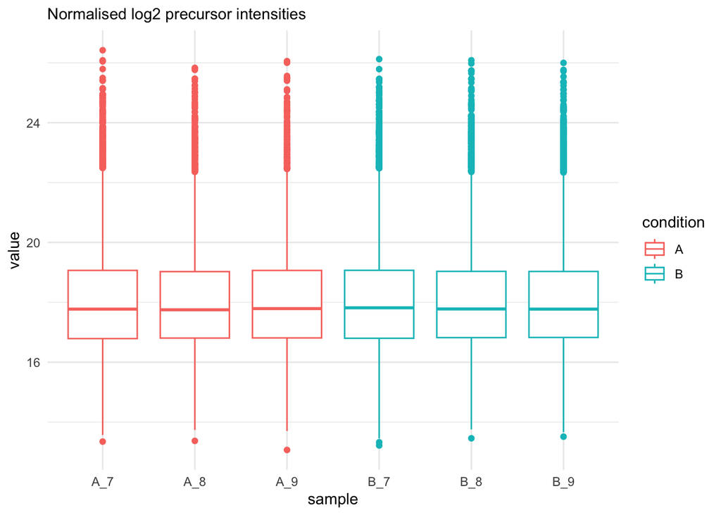

```r
qf[, , "peptides_norm"] |>
  longForm(colvars = colnames(colData(qf))) |>
  data.frame() |>
  filter(!is.na(value)) |>
  ggplot() +
  aes(x = sampleId,
      y = value,
      colour = condition,
      group = colname) +
  xlab("sample") +
  geom_boxplot() +
  theme_minimal() +
   labs(subtitle = "Normalised log2 precursor intensities")
```

We do the same for the protein-level values.

```
harmonizing input:
  removing 18 sampleMap rows not in names(experiments)
```

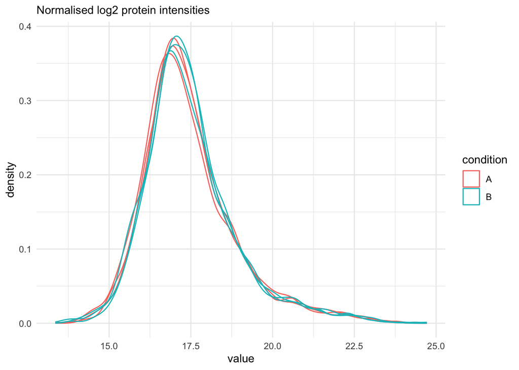

```r
qf[, , "proteins"] |>
  longForm(colvars = colnames(colData(qf))) |>
  data.frame() |>
  filter(!is.na(value)) |>
  ggplot() +
  aes(x = value,
      colour = condition,
      group = colname) +
  geom_density() +
  theme_minimal() +
   labs(subtitle = "Normalised log2 protein intensities")
```

```
harmonizing input:
  removing 18 sampleMap rows not in names(experiments)
```

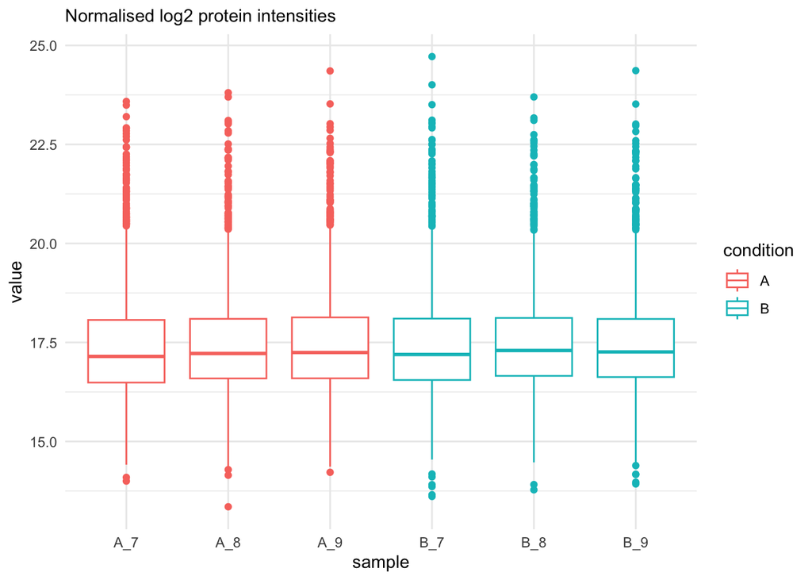

```r
qf[, , "proteins"] |>
  longForm(colvars = colnames(colData(qf))) |>
  data.frame() |>
  filter(!is.na(value)) |>
  ggplot() +
  aes(x = sampleId,
      y = value,
      colour = condition,
      group = colname) +
  xlab("sample") +
  geom_boxplot() +
  theme_minimal() +
   labs(subtitle = "Normalised log2 protein intensities")
```

## 6.2 Identifications per sample

```
harmonizing input:
  removing 18 sampleMap rows not in names(experiments)
```

```
`summarise()` has regrouped the output.
ℹ Summaries were computed grouped by condition and sampleId.
ℹ Output is grouped by condition.
ℹ Use `summarise(.groups = "drop_last")` to silence this message.
ℹ Use `summarise(.by = c(condition, sampleId))` for per-operation grouping
  (`?dplyr::dplyr_by`) instead.
```

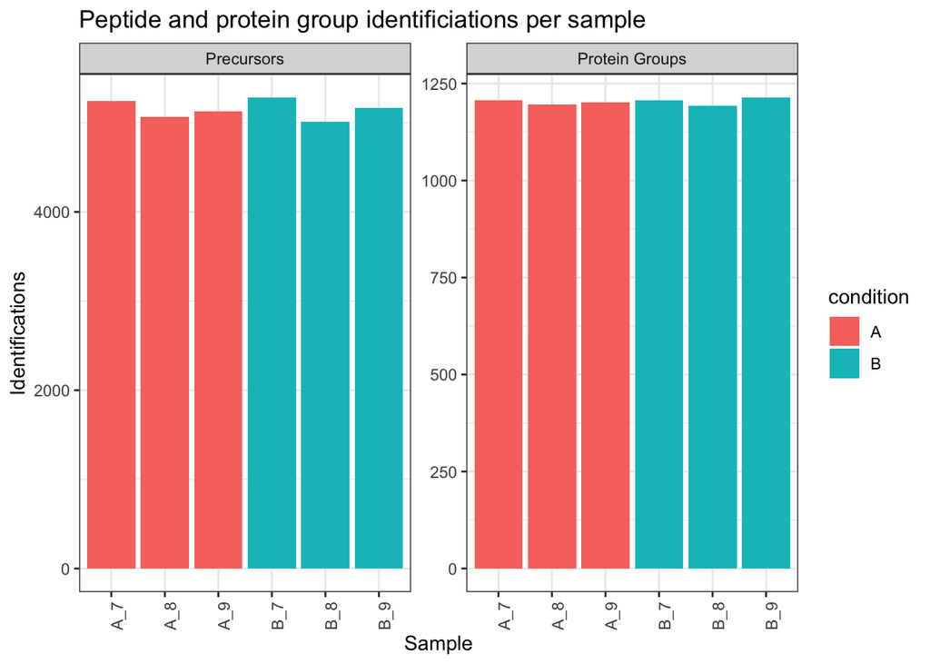

```r
qf[,,"peptides_norm"] |>
  longForm(colvars = colnames(colData(qf)),
           rowvars= c("Sequence",
                      "Proteins")) |>
  data.frame() |>
  filter(!is.na(value)) |>
  group_by(condition, sampleId) |>
  summarise(Precursors = length(unique(Sequence)),
            `Protein Groups` = length(unique(Proteins))) |>
  pivot_longer(-(1:2),
               names_to = "Feature",
               values_to = "IDs") |>
  ggplot(aes(x = sampleId, y = IDs, fill = condition)) +
  geom_col() +
  #scale_fill_observable() +
  facet_wrap(~Feature,
             scales = "free_y") +
  labs(title = "Peptide and protein group identificiations per sample",
       x = "Sample",
       y = "Identifications") +
  theme_bw() +
  theme(axis.text.x = element_text(angle = 90))
```

## 6.3 Dimensionality reduction plot

A common approach for data exploration is to perform dimension reduction, such as Multi Dimensional Scaling (MDS). We will first extract the set to explore along the sample annotations (used for plot colouring).

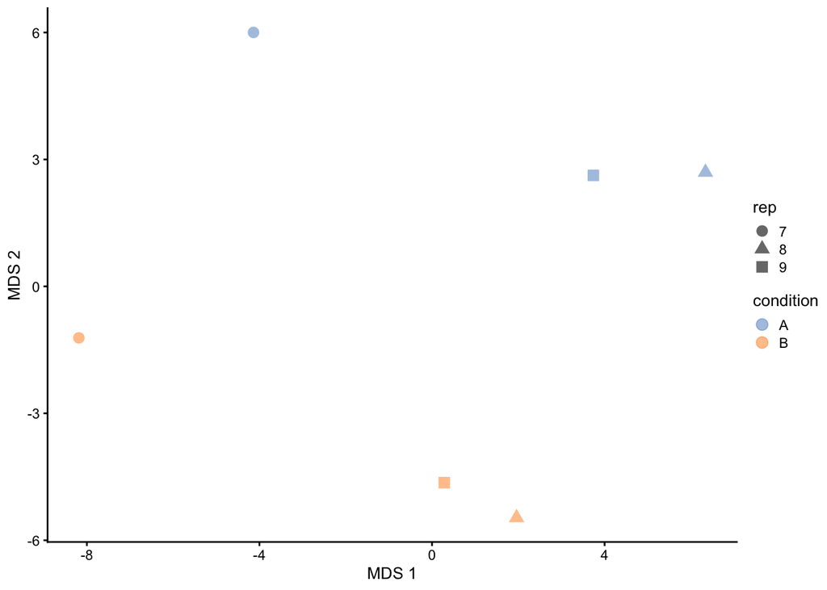

```r
getWithColData(qf, "proteins") |>
  as("SingleCellExperiment") |>
  runMDS(exprs_values = 1) |>
  plotMDS(colour_by = "condition", shape_by = "rep", point_size = 3)
```

This plot reveals interesting information. First, we see that the samples are nicely separated according to their spike-in condition. The also seem to line up according to `rep`.

## 6.4 Correlation matrix

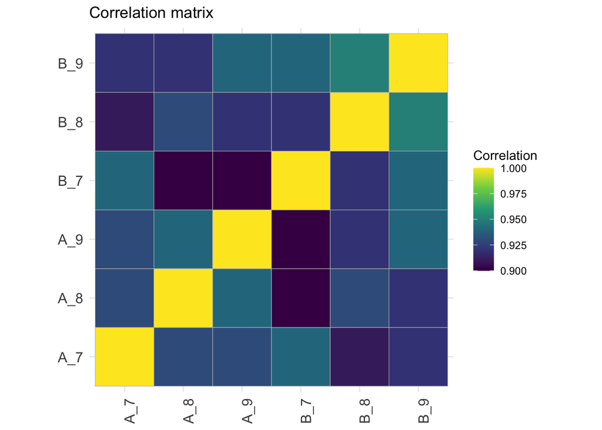

```r
corMat <- qf[["proteins"]] |>
  assay() |>
  cor(method = "spearman", use = "pairwise.complete.obs")

colnames(corMat) <- qf$sampleId
rownames(corMat) <- qf$sampleId
corMat |>
  ggcorrplot::ggcorrplot() +
  scale_fill_viridis_c() +
  labs(title = "Correlation matrix",
       fill = "Correlation") +
  theme(axis.text.x = element_text(angle = 90))
```

# 7 Data Modeling (Robust Regression)

## 7.1 Sources of variation

For this experiment, we can only model a single source of variation: spike-in concentration. All remaining sources of variability, e.g. pipetting errors, MS run to run variability, etc will be lumped in the residual variability (error term).

Spike-in condition effects: we model the source of variation induced by the experimental treatment of interest as a fixed effect, which we consider non-random, i.e. the treatment effect is assumed to be the same in repeated experiments, but it is unknown and has to be estimated.

When modelling a typical label-free experiment at the protein level, the model boils down to the following linear model:

$$y_i = \mathbf{x}_i^T\boldsymbol{\beta} +\epsilon_i$$
with the $\log_2$-normalised and summarised protein intensities in sample; $\mathbf{x}_i$ a vector with the covariate pattern for the sample encoding the intercept, spike-in condition, or other experimental factors;
$\boldsymbol{\beta}$ the vector of parameters that model the association between the covariates and the outcome; and $\epsilon_i$ the residuals reflecting variation that is not captured by the fixed effects. Note that allows for a flexible parameterisation of the treatment beyond a single covariate, i.e. including a 1 for the intercept, continuous and categorical variables as well as their interactions. We assume the residuals to be independent and identically distributed (i.i.d) according to a normal distribution with zero mean and constant variance, i.e. $\epsilon_i \sim N(0, \sigma^2_\epsilon)$, that can differ from protein to protein.

In R, this model is encoded using the following simple formula:

```r
model <- ~ condition
```

## 7.2 Model Estimation

We estimate the model with `msqrob()`. The function takes the QFeatures object, extracts the quantitative values from the `"proteins"` set generated during summarisation, and fits a simple linear model with `condition` as covariate, which are automatically retrieved from `colData(qf)`. Note, that `msqrob()` can also take a `SummarizedExperiment` of precursor, peptide or protein intensities as its input.

```r
  qf <- msqrob(
    qf,
    i = "proteins",
    formula = model,
    robust = TRUE)
```

We enable M-estimation (`robust = TRUE`) for improved robustness against outliers.

The fitting results are available in the `msqrobModels` column of the rowData. More specifically, the modelling output is stored in the `rowData` as a `statModel` object, one model per row (protein). We will see in a later section how to perform statistical inference on the estimated parameters.

```r
models <- rowData(qf[["proteins"]])[["msqrobModels"]]
models[1:3]
```

```
$`O00762ups|UBE2C_HUMAN_UPS`
Object of class "StatModel"
The type is "rlm"
There number of elements is 7

$`P00167ups|CYB5_HUMAN_UPS`
Object of class "StatModel"
The type is "rlm"
There number of elements is 7

$`P00441ups|SODC_HUMAN_UPS`
Object of class "StatModel"
The type is "rlm"
There number of elements is 7
```

## 7.3 Statistical inference

We can now convert the research question “do the spike-in conditions affect the protein intensities?” into a statistical hypothesis.

In other words, we need to translate this question in a null and alternative hypothesis on a single model parameter or on a linear combination of model parameters, which is also referred to with a contrast.

To aid defining contrasts, we will visualise the experimental design using the `ExploreModelMatrix` package.

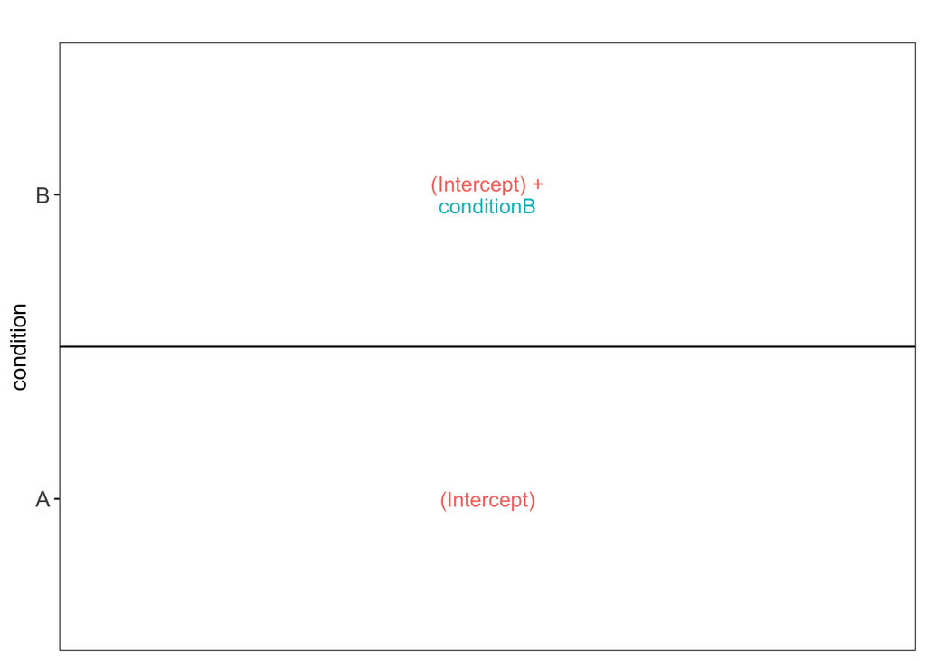

```r
vd <- ExploreModelMatrix::VisualizeDesign(
    sampleData =  colData(qf),
    designFormula = model,
    textSizeFitted = 4
)
vd$plotlist
```

This plot shows that the average protein $\log_2$ intensity for conditionA is modelled by `(Intercept)` and that for the `conditionB` group by `(Intercept) + conditionB` .

Hence, to assess differential abundance of proteins between the two spike-in conditions, we will have to assess the following null hypothesis: $\log_2 FC_{B-A} = (Intercept + conditionB) - Intercept = conditionB = 0$.

Based on this null hypothesis we now generate a contrast matrix.

```r
(L <- makeContrast(
  "conditionB = 0",
  parameterNames = colnames(vd$designmatrix)
))
```

```
            conditionB
(Intercept)          0
conditionB           1
```

We can now test our null hypothesis using `hypothesisTest()` which takes the `QFeatures` object with the fitted model and the contrast we just built. `msqrob2` automatically applies the hypothesis testing to all features in the assay.

```r
qf <- hypothesisTest(qf, i = "proteins", contrast = L)
```

The results tables for the contrast are stored in the row data of the `proteins` assay in `qf` under the colomnames of the contrast matrix `L`.

```r
inferences <-
  msqrobCollect(qf[["proteins"]], L)
head(inferences)
```

```
                                         logFC        se       df         t
conditionB.O00762ups|UBE2C_HUMAN_UPS  1.544695 0.1464716 5.726358 10.546038
conditionB.P00167ups|CYB5_HUMAN_UPS         NA        NA 5.000874        NA
conditionB.P00441ups|SODC_HUMAN_UPS  -0.421279 0.1780461 6.000874 -2.366123
conditionB.P00709ups|LALBA_HUMAN_UPS  1.333640 0.4673775 6.000874  2.853453
conditionB.P00915ups|CAH1_HUMAN_UPS   0.000000        NA       NA        NA
conditionB.P00918ups|CAH2_HUMAN_UPS   1.477407 0.1891851 7.000874  7.809320
                                             pval     adjPval   contrast
conditionB.O00762ups|UBE2C_HUMAN_UPS 5.769185e-05 0.005750616 conditionB
conditionB.P00167ups|CYB5_HUMAN_UPS            NA          NA conditionB
conditionB.P00441ups|SODC_HUMAN_UPS  5.580925e-02 0.910029883 conditionB
conditionB.P00709ups|LALBA_HUMAN_UPS 2.904513e-02 0.744439354 conditionB
conditionB.P00915ups|CAH1_HUMAN_UPS            NA          NA conditionB
conditionB.P00918ups|CAH2_HUMAN_UPS  1.062242e-04 0.009571350 conditionB
                                                       feature
conditionB.O00762ups|UBE2C_HUMAN_UPS O00762ups|UBE2C_HUMAN_UPS
conditionB.P00167ups|CYB5_HUMAN_UPS   P00167ups|CYB5_HUMAN_UPS
conditionB.P00441ups|SODC_HUMAN_UPS   P00441ups|SODC_HUMAN_UPS
conditionB.P00709ups|LALBA_HUMAN_UPS P00709ups|LALBA_HUMAN_UPS
conditionB.P00915ups|CAH1_HUMAN_UPS   P00915ups|CAH1_HUMAN_UPS
conditionB.P00918ups|CAH2_HUMAN_UPS   P00918ups|CAH2_HUMAN_UPS
```

### 7.3.1 Results table for significant proteins

We will return a table of proteins for which the contrast is significant at the 5% FDR level.

1. We set the significance level
2. We filter the significant results for the contrast from the table
3. We print the table

```r
alpha <- 0.05 #1.
sigList <- inferences |>
    filter(adjPval < alpha) #3.
kable(sigList) |>
      kable_styling(full_width = FALSE) |>
      scroll_box(height = "250px") #4.
```

|  | logFC | se | df | t | pval | adjPval | contrast | feature |
| --- | --- | --- | --- | --- | --- | --- | --- | --- |
| conditionB.O00762ups&#124;UBE2C_HUMAN_UPS | 1.544695 | 0.1464716 | 5.726358 | 10.546038 | 0.0000577 | 0.0057506 | conditionB | O00762ups&#124;UBE2C_HUMAN_UPS |
| conditionB.P00918ups&#124;CAH2_HUMAN_UPS | 1.477407 | 0.1891851 | 7.000874 | 7.809320 | 0.0001062 | 0.0095713 | conditionB | P00918ups&#124;CAH2_HUMAN_UPS |
| conditionB.P01031ups&#124;CO5_HUMAN_UPS | 1.767896 | 0.1930014 | 5.463533 | 9.160019 | 0.0001614 | 0.0118909 | conditionB | P01031ups&#124;CO5_HUMAN_UPS |
| conditionB.P01127ups&#124;PDGFB_HUMAN_UPS | 1.481764 | 0.1687895 | 6.818259 | 8.778764 | 0.0000585 | 0.0057506 | conditionB | P01127ups&#124;PDGFB_HUMAN_UPS |
| conditionB.P01344ups&#124;IGF2_HUMAN_UPS | 1.489747 | 0.1250054 | 6.000874 | 11.917465 | 0.0000211 | 0.0031115 | conditionB | P01344ups&#124;IGF2_HUMAN_UPS |
| conditionB.P01375ups&#124;TNFA_HUMAN_UPS | 1.866765 | 0.2350145 | 6.000874 | 7.943191 | 0.0002115 | 0.0146690 | conditionB | P01375ups&#124;TNFA_HUMAN_UPS |
| conditionB.P02144ups&#124;MYG_HUMAN_UPS | 1.390209 | 0.2214167 | 6.970553 | 6.278698 | 0.0004196 | 0.0274861 | conditionB | P02144ups&#124;MYG_HUMAN_UPS |
| conditionB.P02787ups&#124;TRFE_HUMAN_UPS | 1.490130 | 0.1488114 | 6.578795 | 10.013545 | 0.0000320 | 0.0041878 | conditionB | P02787ups&#124;TRFE_HUMAN_UPS |
| conditionB.P06732ups&#124;KCRM_HUMAN_UPS | 1.635848 | 0.1366995 | 7.000874 | 11.966742 | 0.0000065 | 0.0019071 | conditionB | P06732ups&#124;KCRM_HUMAN_UPS |
| conditionB.P07339ups&#124;CATD_HUMAN_UPS | 1.929497 | 0.1809218 | 6.000874 | 10.664812 | 0.0000400 | 0.0047210 | conditionB | P07339ups&#124;CATD_HUMAN_UPS |
| conditionB.P08311ups&#124;CATG_HUMAN_UPS | 1.561305 | 0.1045255 | 7.000874 | 14.937069 | 0.0000014 | 0.0005676 | conditionB | P08311ups&#124;CATG_HUMAN_UPS |
| conditionB.P09211ups&#124;GSTP1_HUMAN_UPS | 1.197007 | 0.1773925 | 5.861064 | 6.747789 | 0.0005697 | 0.0335809 | conditionB | P09211ups&#124;GSTP1_HUMAN_UPS |
| conditionB.P10636-8ups&#124;TAU_HUMAN_UPS | 1.282407 | 0.1153671 | 7.000874 | 11.115878 | 0.0000106 | 0.0019071 | conditionB | P10636-8ups&#124;TAU_HUMAN_UPS |
| conditionB.P12081ups&#124;SYHC_HUMAN_UPS | 1.439463 | 0.1714347 | 6.000874 | 8.396564 | 0.0001553 | 0.0118909 | conditionB | P12081ups&#124;SYHC_HUMAN_UPS |
| conditionB.P51965ups&#124;UB2E1_HUMAN_UPS | 1.664890 | 0.1512672 | 7.000874 | 11.006286 | 0.0000113 | 0.0019071 | conditionB | P51965ups&#124;UB2E1_HUMAN_UPS |
| conditionB.P61769ups&#124;B2MG_HUMAN_UPS | 2.012769 | 0.3340379 | 6.965852 | 6.025572 | 0.0005386 | 0.0334228 | conditionB | P61769ups&#124;B2MG_HUMAN_UPS |
| conditionB.P63165ups&#124;SUMO1_HUMAN_UPS | 1.062479 | 0.1375085 | 7.000874 | 7.726642 | 0.0001137 | 0.0095713 | conditionB | P63165ups&#124;SUMO1_HUMAN_UPS |
| conditionB.P63279ups&#124;UBC9_HUMAN_UPS | 1.822523 | 0.1165455 | 7.000874 | 15.637873 | 0.0000011 | 0.0005676 | conditionB | P63279ups&#124;UBC9_HUMAN_UPS |
| conditionB.P99999ups&#124;CYC_HUMAN_UPS | 2.061623 | 0.1372066 | 7.000874 | 15.025690 | 0.0000014 | 0.0005676 | conditionB | P99999ups&#124;CYC_HUMAN_UPS |
| conditionB.Q06830ups&#124;PRDX1_HUMAN_UPS | 1.582654 | 0.1418741 | 7.000874 | 11.155343 | 0.0000104 | 0.0019071 | conditionB | Q06830ups&#124;PRDX1_HUMAN_UPS |

### 7.3.2 Volcanoplots

Experienced users can make the plot themselves. However, in msqrob2 we also provide the plotVolcano function that generates volcanoplots based on `msqrob2` inference tables generated with the `hypothesisTest` function.

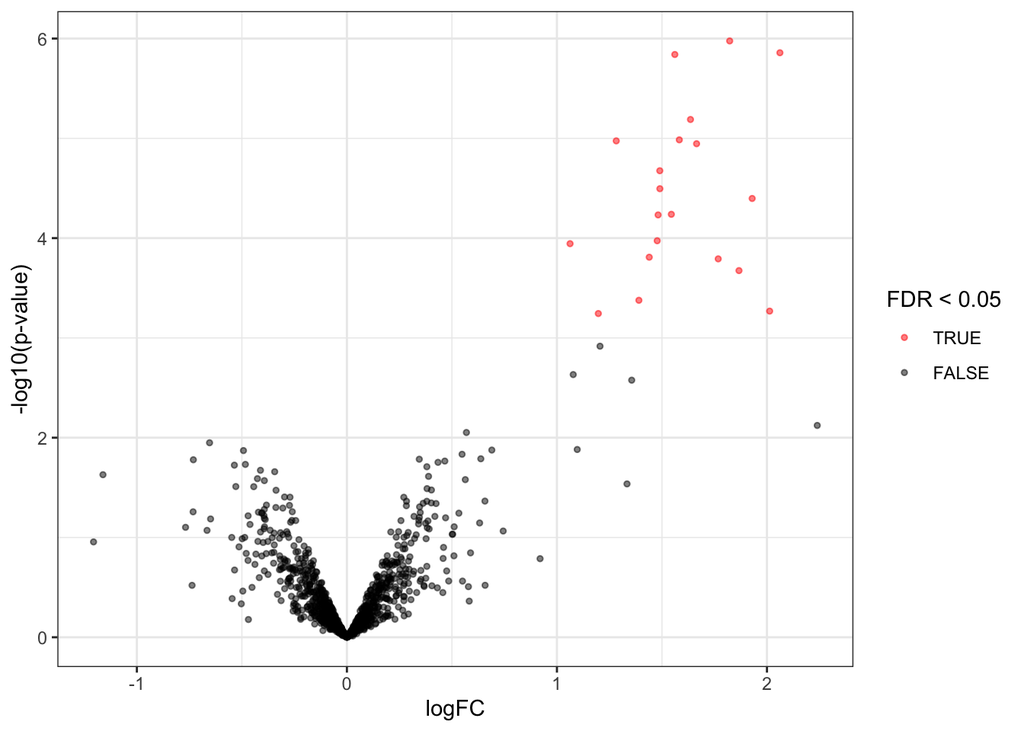

```r
inferences |>
  plotVolcano()
```

### 7.3.3 Heatmaps

We construct heatmaps for the significant proteins for each contrast.

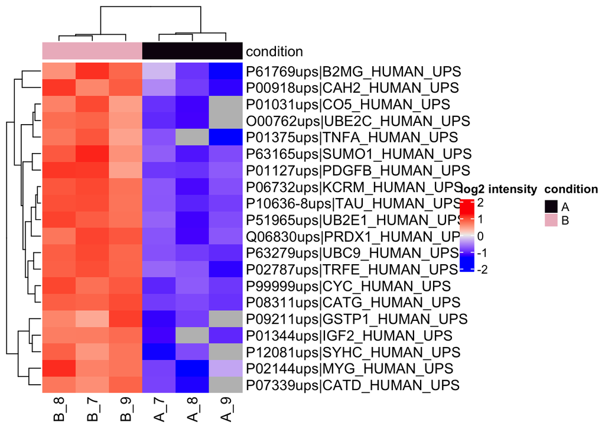

```r
sig <- sigList |> pull(feature) #1.


quants <- assay(qf,"proteins")[sig,] |>
                     t() |>
                     scale() |>
                     t() #2.

colnames(quants) <- qf$sampleId #3.
annotations <- columnAnnotation(condition = qf$condition) #3.

set.seed(1234) ## annotation colours are randomly generated by default
Heatmap(
  quants,
  name = "log2 intensity",
  top_annotation = annotations
  )  #4.
```

Note, that 20 DA proteins are returned and that they are all UPS proteins!

A typical workflow for the analysis of a proteomics experiment will end here.

# 8 References

Note, that more examples can be found in our [msqrob2 book](https://statomics.github.io/msqrob2book).

## Footnotes

[^1]: Note, that upon this transformation a value of 1 represents a p-value of 0.1, 2 a p-value of 0.01, 3 a p-value of 0.001, etc.